# CMarinExcercise

Linli Zhou

2022-08-29

The dataset used for this project contains the number of students enrolling in their first English course at a university who enrolled in transfer-level or below transfer-level English by term and race/ethnicity.

Context: Assembly Bill 705 (Title 5, § 55003 and 55522) requires all California Community Colleges to design placement methods that maximize the probability that students will enter and complete transfer-level coursework in English and math/quantitative reasoning within one year of their first enrollment in the discipline. In the databset, the university’s methods used to determine placement changed from a placement test in fall 2015 and 2016, to multiple measures in fall 2017 and 2018, to AB705 in fall 2019.

Research Question” How did the change in placement methods impact placement into transfer-level English?

```r
data<-read_excel("/Users/linlizhou/Documents/LASELL/CMarinExcercise.xlsx",sheet = "raw")
```

```r
#transform pivot table into one observation each row
data.l<-pivot_longer(data,cols = `Fall 2015 (placement test)`:`Fall 2019 (AB705)`,names_to = "Term.Method",values_to = "NumberPlacement")
```

```r
#Year col
data.l<-data.l%>%mutate(Year=case_when(
  Term.Method=="Fall 2015 (placement test)"~"2015",
  Term.Method=="Fall 2016 (placement test)"~"2016",
  Term.Method=="Fall 2017 (Multiple measures)"~"2017",
  Term.Method=="Fall 2018 (Multiple measures)"~"2018",
  Term.Method=="Fall 2019 (AB705)"~"2019"
))

#method col
data.l<-data.l%>%mutate(Method=case_when(
  Term.Method=="Fall 2015 (placement test)"~"Placement test",
  Term.Method=="Fall 2016 (placement test)"~"Placement test",
  Term.Method=="Fall 2017 (Multiple measures)"~"Multiple measures",
  Term.Method=="Fall 2018 (Multiple measures)"~"Multiple measures",
  Term.Method=="Fall 2019 (AB705)"~"AB705"
))

#save raw and tidy sheets in the same excel workbook
write.xlsx(list("tidy"=data.l,"raw"=data), file="/Users/linlizhou/Documents/LASELL/CMarinExcercise.xlsx")
```

```r
data.l$Method=factor(data.l$Method, levels=c("Placement test","Multiple measures","AB705"),labels=c("Placement Test (2015/16)","Multiple Measures (2017/18)","AB705 (2019)")) #recode the levels
```

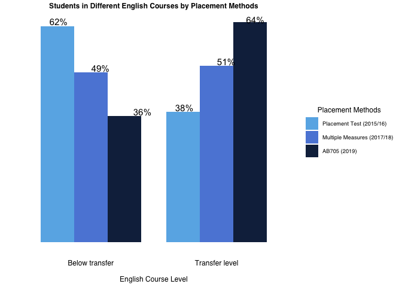

```r
aggregate(data.l$NumberPlacement,by=list(Method=data.l$Method,Level=data.l$Course),FUN="sum")%>%#aggragated table with all vars needed
  group_by(Method)%>%mutate(prt=x/sum(x)) %>% #group by whatever is going to be the larger groups (adds up to 100%)
ggplot(aes(x=Level,y=percent(prt,digit=0),fill=Method))+
   geom_bar(stat="identity",position=position_dodge(),width = 0.8)+
  geom_text_repel(aes(label=percent(prt,digits=0)),color="black",size=4,position = position_dodge(width = 1),vjust=.9)+# hjust = 1.5 positions them inside the end of the bars. An hjust of 0.5 and a vjust of 0.5 center the box on the reference point. hjust=0, the left edge;;; For vertical, less is up and more is down
  theme_lz()+
    scale_fill_manual(values = c(mycolors[3],mycolors[2],mycolors[1]), name="Placement Methods")+#change legend color, lable, and title
  scale_y_continuous(breaks = seq(0, 0.3, by = 0.1) ,labels = scales::percent)+#present y axis label as percentage
  #geom_text_repel(aes(label= ifelse(Grade2System==4,paste(round(100*prt, 0), "%", sep=""),"")),size=3)+
  labs(x = "English Course Level", y = "", title="Students in Different English Courses by Placement Methods")+
   theme(axis.text.y=element_blank())
```

Conclusion: Each time we change placement methods, there have been around 13% more students to be placed into transfer level than below transfer English course. For example, the latest placement methods (AB705) put 13% more students into transfer level English course than its predecessors (Multiple Measures).

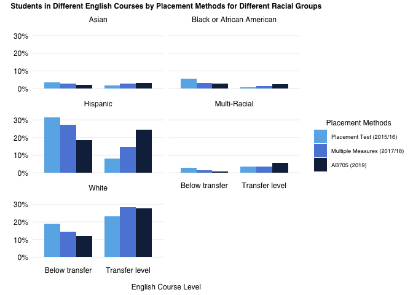

```r
aggregate(data.l$NumberPlacement,by=list(Method=data.l$Method,Level=data.l$Course, Race=data.l$Race),FUN="sum")%>%#aggragated table with all vars needed
  group_by(Method)%>%mutate(prt=x/sum(x)) %>% #group by whatever is going to be the larger groups (adds up to 100%)
ggplot(aes(x=Level,y=percent(prt,digit=0),fill=Method))+
   geom_bar(stat="identity",position=position_dodge(),width = 0.8)+
  facet_wrap(~Race,ncol=2)+
  #geom_text_repel(aes(label=percent(prt,digits=0)),color="black",size=4,position = position_dodge(width = 1),vjust=.9)+# hjust = 1.5 positions them inside the end of the bars. An hjust of 0.5 and a vjust of 0.5 center the box on the reference point. hjust=0, the left edge;;; For vertical, less is up and more is down
  theme_lz()+
    scale_fill_manual(values = c(mycolors[3],mycolors[2],mycolors[1]), name="Placement Methods")+#change legend color, lable, and title
  scale_y_continuous(breaks = seq(0, 0.3, by = 0.1) ,labels = scales::percent)+#present y axis label as percentage
  #geom_text_repel(aes(label= ifelse(Grade2System==4,paste(round(100*prt, 0), "%", sep=""),"")),size=3)+
  labs(x = "English Course Level", y = "", title="Students in Different English Courses by Placement Methods for Different Racial Groups")+
  theme(panel.grid.major.y = element_line(colour = "grey95"))
```